# Personality and plasticity predicts post-release performance in a reintroduced mesopredator

Wilson B A, Evans M J, Gordon I J, Banks S C, Batson W G, Wimpenny C, Newport J, & Manning A D

1 October 2023

# 1 **Background**

Personality can play a crucial role in the survival and dispersal of reintroduced animals. In 2017, we reintroduced a cohort of female-only eastern quolls (*Dasyurus viverrinus*) to a [conservation-fenced haven](https://www.mulligansflat.org.au/) in the Australian Capital Territory, and conducted behavioural assays on each animal prior to their release. We aimed to determine whether personality and plasticity of these animals could predict their post-release performance.

Here we describe the analyses we conducted for our article [Wilson *et al.* (2022) Personality and plasticity predicts post-release performance in a reintroduced mesopredator](https://doi.org/10.1016/j.anbehav.2022.02.019), published in Animal Behaviour.

# 2 **Setup**

First, we installed the [pacman Package Management Tool](https://cran.r-project.org/web/packages/pacman/index.html), which allows us to install and load subsequent packages in a condensed and efficient way.

```r
#install.packages("pacman")
```

```r
# Install and load required packages
pacman::p_load(adehabitatHR, brglm, corrplot, factoextra,
               FactoMineR, ggplot2, ggpubr, grid, gridExtra,
               gtools, lme4, magrittr, raster, RColorBrewer,
               readr, readxl, rstudioapi, tidyverse)
```

We also set the working directly to where this R markdown is saved using the `rstudioapi` package.

```r
# Set the working directory to where this markdown is saved
setwd(dirname(rstudioapi::getActiveDocumentContext()$path))
```

# 3 **Data preparation**

## 3.1 Behavioural assays

### 3.1.1 Scale variables

1. Latency to `emerge` (min)
2. Latency to reach `food` (min)
3. Time spent `active`
4. Time spent `vigil`ant
5. Time spent `hid`den
6. Time spent exposed (`out`)
7. Giving-up density (%, `gud`)
8. Number of camera triggers (*n*):
   - Total `trig`gers (not used)
   - Triggers in far half of enclosure (`trigpass`)

Because the enclosures were open to the elements, we needed to account for environmental heteroegeneity by adjusting our behavioural responses to these covariates, with values collected around the time of the assay (18:00 or 21:00):

1. Ambient `temp`erature (°C)
2. `precip`itation (mm)
3. Relative `humid`ity (%)
4. Mean `wind` speed
5. `press`ure (hPa)
6. `moon` phase (%)

```r
# Assign raw data filename to an object
raw_data <- "data.xlsx"

# Read in behavioural assay data
assay <- read_excel(raw_data, sheet="behavioural assays")
assay < mutate_at(assay, c(11, 14:20, 26,28, 30:32, 34, 36:37), funs(c(scale(.))))
```

[output not shown]

[output cut: 1110 more lines]

```r
write.csv(assay, "processed data/behavioural assays.csv")

# Read in behavioural assay data
assay <- read_excel(raw_data, sheet="behavioural assays") %>%
  mutate_at(c(11, 14:20, 26,28, 30:32, 34, 36:37),
            funs(c(scale(.))))
write.csv(assay, "processed data/behavioural assays.csv")
```

### 3.1.2 Predict behavioural responses

Here, we modelled each animal’s behavioural response (`emerge`, `food`, `active`, `vigil`, `out`, `hid`, `gud`, and `trigpass`) including environmental covariates, and predict their responses after accounting for these covariates.

We then extracted each model’s intercept (personality) and slope (plasticity) coefficients for analyses (i.e., the behavioural reaction norm approach, [Dingemanse *et al*. 2010](https://doi.org/10.1016/j.tree.2009.07.013)).

```r
# Create a list of dependent behavioural variables
dependent <- c("emerge","food","active","vigil",
               "out","hid","gud","trigpass")

# Define the levels in an object
quolls <- levels(factor(assay$individual))

# Create a blank dataframe with four columns
coefficients <- data.frame(individual=NULL, intercept=NULL,
                           slope=NULL, variable=NULL)

# Loop to extract the intercept and slope of each behavioural response
for(v in 1:NROW(dependent)) {
  for(i in 1:NROW(quolls)){
    individual <- quolls[i]
    variable <- dependent[v]
    mod <- lm(eval(as.name(paste0(variable))) ~
                observation + temp + precip + humid +
                wind + press + moon + cue + cycle + session,
              data=subset(assay, individual==quolls[i]))
    i <- coef(mod)[1]
    s <- coef(mod)[2]
    results <- data.frame(cbind(individual, i, s, variable))
    coefficients <- rbind(coefficients, results)
  }
}

# Convert the df to wide format
coefficients <- reshape(coefficients, idvar="individual",
                        timevar="variable", direction="wide")

# Define names of the coefficients
names(coefficients) <- gsub("\\.", "_", names(coefficients))

# Remove duplicated coefficients
coefficients <- coefficients[ , !duplicated(colnames(coefficients))]

# Join behavioural df with post-release df
post <- read_excel(raw_data, sheet="post-release performance") %>%
  left_join(coefficients, by="individual")

# Remove duplicated column names
post <- post[ , !duplicated(colnames(post))]

# Write to csv file
write_csv(post, "processed data/post-release performance.csv")
```

## 3.2 Post-release data

Here we calculate three of the dispersal-related post-release responses for each animal in the first 42 days post-release: `first_night`, `mean_dist`, and `hr95`.

### 3.2.1 First night distance

Firstly, we calculate the distance each animal travelled between its release site and its first daytime den.

```r
# Read in post-release data
post <- read_csv("processed data/post-release performance.csv",
                 col_types=cols())

# Create release coordinates dataframe
rcoord <- data.frame(post$release_easting, post$release_northing)

# Create first night den coordinates
fcoord <- data.frame(post$first_night_easting, post$first_night_northing)

# Measure distance between release and first night den coordinates
post$first_dist <- raster::pointDistance(rcoord, fcoord, lonlat=FALSE)

# Create column names
first_night <- post[c("individual", "first_dist")]

# Join column names with post-release responses
post <- left_join(first_night, post, by="individual")

# Remove duplicated column names
post <- post[ , !duplicated(colnames(post))]

# Write to csv file
write.csv(post, "processed data/post-release indices.csv", row.names=FALSE)
```

### 3.2.2 Mean distance between dens

Next, we calculated the mean distance between each animal’s dens (as per [Wilson et al 2020](https://journals.plos.org/plosone/article?id=10.1371/journal.pone.0234455), the code for which is available in [ANU Data Commons](https://datacommons.anu.edu.au/DataCommons/rest/display/anudc:6063?layout=def:display)).

### 3.2.3 Home range

Finally, we calculated home range as [95% MCPs](https://bit.ly/3lYGxxZ).

```r
# Read in den data
den <- read_excel(raw_data, sheet="den locations")

# Define column names
den <- den[, c("Individual", "Easting", "Northing")]

# Read in post-release data
post <- read.csv("processed data/post-release indices.csv")

# Create a den coordinates df
coordinates(den) <- c("Easting", "Northing")

# Define the den coordinates projection (warnings okay)
proj4string(den) <- CRS("+proj=utm +zone=55 +ellps=WGS84 +units=m +no_defs")

# Calculate MCP per individual (warnings okay)
hr95 <- data.frame(mcp(den, percent=95))

# Define the column name for the first row
names(hr95)[1] <- "individual"

# Join the post-release df to the home range df
post <- left_join(post, hr95, by="individual") %>%
  mutate(hr95=area)

# Write to csv file
write_csv(post, "processed data/post-release indices.csv")
```

# 4 **Model behaviour by observation number**

## 4.1 Models

Here we modelled each of the behavioural responses against observation number, and extracted the *p*-values for inclusion in later plots.

```r
# Read in behavioural assay data
assay <- read.csv("processed data/behavioural assays.csv")

# Create a list of behavioural measure names
dependent <- c("emerge","food","active","vigil", "out","hid","gud","trigpass")

# Create a df with two columns
pvalues <- data.frame(pvalue=NULL, variable=NULL)

# Generate a linear model of the food response by obervation number
summary(lm(food ~ observation, data=assay, na.action="na.fail"))
```

```
##
## Call:
## lm(formula = food ~ observation, data = assay, na.action = "na.fail")
##
## Residuals:
##      Min       1Q   Median       3Q      Max
## -1.69156 -0.96346 -0.00503  1.00187  1.39534
##
## Coefficients:
##             Estimate Std. Error t value Pr(>|t|)
## (Intercept)  0.30405    0.13854   2.195   0.0292 *
## observation -0.03577    0.01433  -2.497   0.0133 *
## ---
## Signif. codes:  0 '***' 0.001 '**' 0.01 '*' 0.05 '.' 0.1 ' ' 1
##
## Residual standard error: 0.9885 on 222 degrees of freedom
## Multiple R-squared:  0.02731,    Adjusted R-squared:  0.02293
## F-statistic: 6.234 on 1 and 222 DF,  p-value: 0.01326
```

```r
for(v in 1:NROW(dependent)) {
  variable <- dependent[v]
  mod <- lm(eval(as.name(paste0(variable))) ~ observation,
               data=assay, na.action="na.fail")
  pvalue <- as.numeric(coef(summary(mod))[8])
  rsquared <- summary(mod)$r.squared
  fstatistic <- summary(mod)$fstatistic
  results <- data.frame(cbind(variable, fstatistic, rsquared, pvalue))
  pvalues <- rbind(pvalues, results)
  pvalues_observation <- subset(pvalues, fstatistic!=1 & fstatistic!=222)
}
pvalues_observation
```

```
##        variable        fstatistic             rsquared              pvalue
## value    emerge  7.95285714585954     0.03458472855945 0.00523564284149975
## value1     food  6.23357018723735   0.0273122406231628  0.0132617059150208
## value2   active 0.003342674752714 1.50568667680432e-05   0.953947303096296
## value3    vigil  7.08090506179128   0.0309100623636933  0.0083600063519468
## value4      out   1.0541752337815  0.00472609505146735   0.305664856718143
## value5      hid  1.05417523378151  0.00472609505146735   0.305664856718143
## value6      gud  10.5768860324356   0.0454769440457661 0.00132347308556019
## value7 trigpass  1.04798182350293  0.00469845911599504   0.307086558054525
```

## 4.2 Scatterplots

Here we plot each behavioural response against observation number to visualise the change in responses over the assay period.

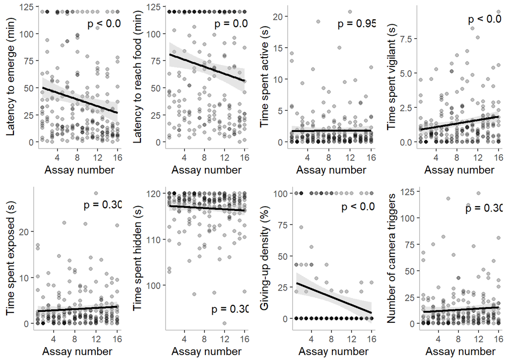

```r
# Read in behavioural assay data
assay <- read_excel(raw_data, sheet="behavioural assays")

# Create list of x-axis labels
xs <- c(14, 14, 14, 14, 14, 14, 14, 14)

# Create list of y-axis labels
ys <- c(110, 110, 19, 9, 26, 95, 90, 110)

# Create list of behavioural measure names
variables <- c("emerge", "food", "active", "vigil",
               "out", "hid", "gud", "trigpass")

# Create list of full behavioural measure labels
names <- c("Latency to emerge (min)", "Latency to reach food (min)",
           "Time spent active (s)", "Time spent vigilant (s)",
          "Time spent exposed (s)", "Time spent hidden (s)",
          "Giving-up density (%)", "Number of camera triggers")

# Create list of p-values for each of the 8 measures
labels <- c("p < 0.01", "p = 0.01", "p = 0.954", "p < 0.01",
          "p = 0.306", "p = 0.306", "p < 0.01", "p = 0.307")

# Loop to plot each of the 8 behavioural measures
figs <- list()
for (i in 1:NROW(variables)) {
  loop_var = as.name(variables[i])
  figs[[i]] <- ggplot(data=assay, mapping=aes_string(x="observation",
                                                     y=loop_var)) +
    geom_point(alpha=0.25) +
    geom_smooth(method="lm", color="black", fill="grey") +
    scale_x_continuous(name="Assay number") +
    scale_y_continuous(name=names[i]) +
    theme(panel.grid.major=element_blank(),
          panel.grid.minor=element_blank(),
          panel.background=element_blank(),
          panel.border=element_blank(),
          axis.line.x=element_line(color="grey"),
          axis.line.y=element_line(color="grey")) +
    annotate("text", x=xs[i], y=ys[i], label=labels[i])
}

# Arrange the eight panels in a single plot
regression <- ggarrange(plotlist=figs, heights=c(3,3,3,3), widths=c(3,3,3,3),
                        font.label=list(size=10, face="bold", color="black"),
                        ncol=4, nrow=2, label.x=0.89, label.y=0.99,
                        hjust=-0.1, vjust=1.5)
# Display plot
print(regression)
```

# 5 **Correlation analysis**

Here we conducted a correlation analysis to compare each behavioural measure to every other behavioural measure, and visualise this in a correlogram.

```r
# Read in post-release data
cor <- read.csv("processed data/post-release indices.csv") %>%
  subset(individual!="EQ25") %>%
  # Extract the intercept and slope for all behavioural responses
  dplyr::select(23:38)

# Generate a correlation matrix
cor <- cor(cor)

# Loop to calculate whether each correlation is significant
cor.mtest <- function(mat, ...) {
    mat <- as.matrix(mat)
    n <- ncol(mat)
    p.mat<- matrix(NA, n, n)
    diag(p.mat) <- 0
    for (i in 1:(n - 1)) {
        for (j in (i + 1):n) {
            tmp <- cor.test(mat[, i], mat[, j], ...)
            p.mat[i, j] <- p.mat[j, i] <- tmp$p.value
        }
    }
  colnames(p.mat) <- rownames(p.mat) <- colnames(mat)
  p.mat
}
```

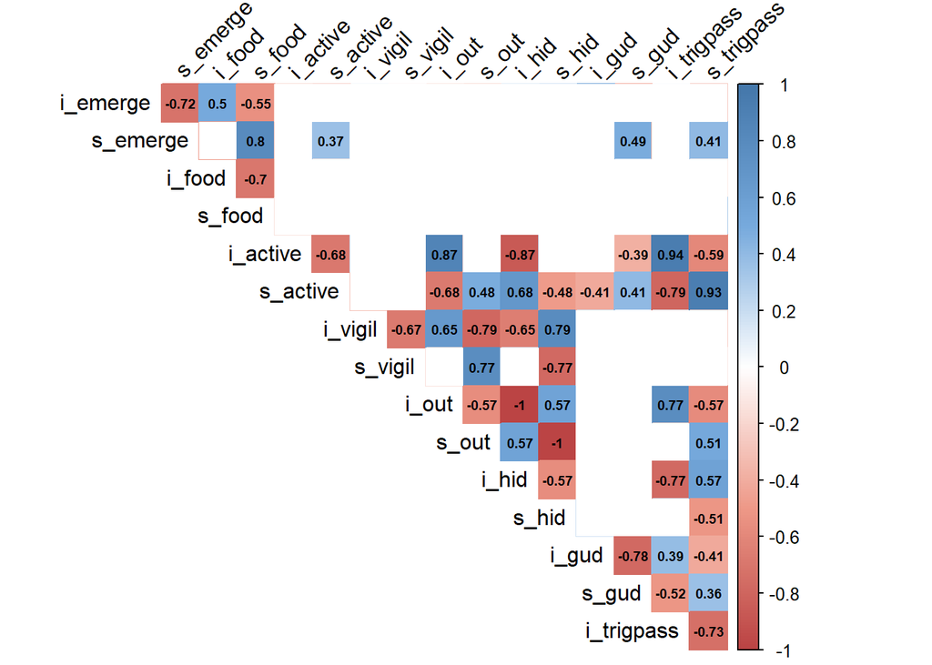

```r
# Generate a correlation matrix
p.mat <- cor.mtest(cor)

# Define colours for correlogram
col <- colorRampPalette(c("#BB4444", "#EE9988", "#FFFFFF",
                          "#77AADD", "#4477AA"))

# Plot the correlation matrix
corrplot(cor, method="color", col=col(200), type="upper",
         addCoef.col="black", tl.col="black", tl.srt=45, p.mat=p.mat,
         sig.level=0.01, insig="blank", diag=FALSE, number.cex=0.6)
```

Our correlation analysis revealed that the following behavioural measures were significant correlated (R > 0.7) with:

- Time spent `out` (or exposed)
- Time spent `active` (time spent `out` - time spent `vigil`),
- Time spent `hid`den (total time - time spent `active` - time spent `vigil`), and
- Number of camera triggers in far half of pen (`trigpass`).

Time spent `out` created the most inter-individual variation, so we dropped `active`, `hid`, and `trigpass` from subsequent analysis.

# 6 **Principle components analysis**

Next, we created PCA variables for the intercept and slope of each remaining behavioural response (`emerge`, `food`, `out`, `vigil`,and `gud`) by extracting the first dimension coordinates for each animal.

“Rather than inferring a particular trait to each of our measures, for clarity we chose to place our results in the context of the proactive (bolder, more exploratory, social) and reactive (shy, less, antisocial) syndrome (Koolhaas et al., 1999; Sih et al., 2004).

We characterized proactive individuals as those with low time spent vigilant, low latency to reach food or emerge, high time spent exposed and high giving-up density, and reactive individuals as those with high time spent vigilant, high latency to reach food or emerge, low time spent exposed and low giving-up density. These were also reflected in the choice of behavioural measures to be included in each of the two PC measures.” [Wilson *et al*. (2022)](https://doi.org/10.1016/j.anbehav.2022.02.019).

```r
# Read in post-release data
post <- read.csv("processed data/post-release indices.csv") %>%
  # Remove one individual that was not released
  subset(individual!="EQ25")

# Define names for each of the 13 eastern quolls
individual <- c('EQ18', 'EQ19', 'EQ20', 'EQ21', 'EQ22',
                'EQ23', 'EQ24', 'EQ26', 'EQ27', 'EQ28',
                'EQ29', 'EQ30', 'EQ31')
```

1. Extract first dimension value of proactive PCA for personality (intercept) for each animal.

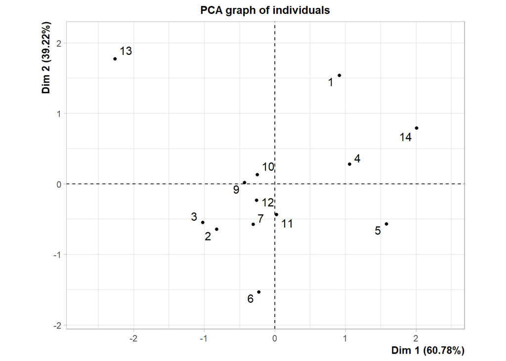

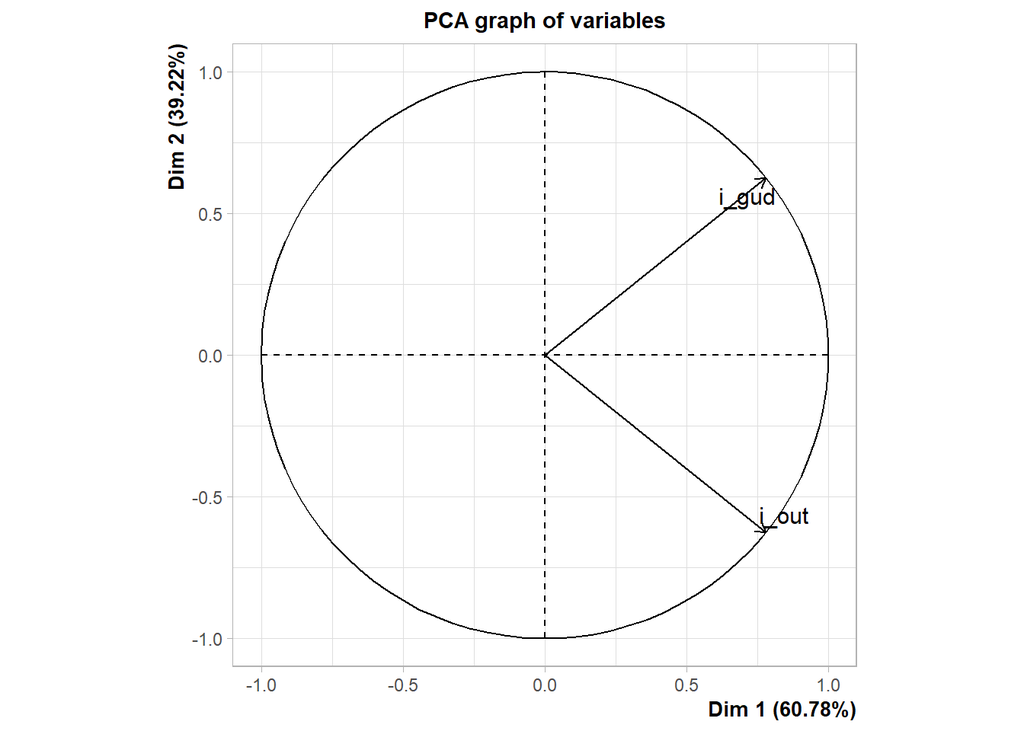

```
##
## Call:
## PCA(X = post[, c(31, 35)])
##
##
## Eigenvalues
##                        Dim.1   Dim.2
## Variance               1.216   0.784
## % of var.             60.780  39.220
## Cumulative % of var.  60.780 100.000
##
## Individuals (the 10 first)
##           Dist    Dim.1    ctr   cos2    Dim.2    ctr   cos2
## 1     |  1.789 |  0.913  5.270  0.260 |  1.539 23.212  0.740 |
## 2     |  1.047 | -0.826  4.315  0.622 | -0.644  4.067  0.378 |
## 3     |  1.160 | -1.023  6.620  0.778 | -0.547  2.932  0.222 |
## 4     |  1.096 |  1.059  7.102  0.934 |  0.281  0.772  0.066 |
## 5     |  1.679 |  1.580 15.801  0.886 | -0.567  3.150  0.114 |
## 6     |  1.551 | -0.225  0.320  0.021 | -1.534 23.082  0.979 |
## 7     |  0.650 | -0.308  0.602  0.225 | -0.572  3.213  0.775 |
## 9     |  0.428 | -0.428  1.158  0.998 |  0.017  0.003  0.002 |
## 10    |  0.279 | -0.248  0.388  0.788 |  0.128  0.162  0.212 |
## 11    |  0.436 |  0.025  0.004  0.003 | -0.435  1.860  0.997 |
##
## Variables
##          Dim.1    ctr   cos2    Dim.2    ctr   cos2
## i_out |  0.780 50.000  0.608 | -0.626 50.000  0.392 |
## i_gud |  0.780 50.000  0.608 |  0.626 50.000  0.392 |
```

```r
# Print PCA graph for behaviours contributing to proactive PCA intercept
summary(PCA(post[,c(31, 35)]))
```

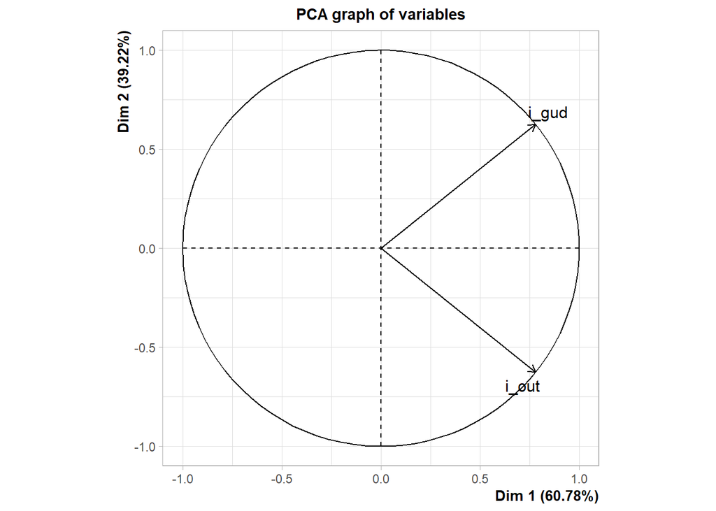

```r
# Extract first dimension value of proactive PCA intercept
i_pro_pca <- get_pca_ind(PCA(post[,c(31, 35)]))
```

```r
i_pro_quoll <- data.frame(individual, i_pro_pca$coord) %>%
  dplyr::select(1, 2) %>%
  rename(i_pro_pca=Dim.1)
```

2. Extract first dimension value of proactive PCA for plasticity (slope) for each animal.

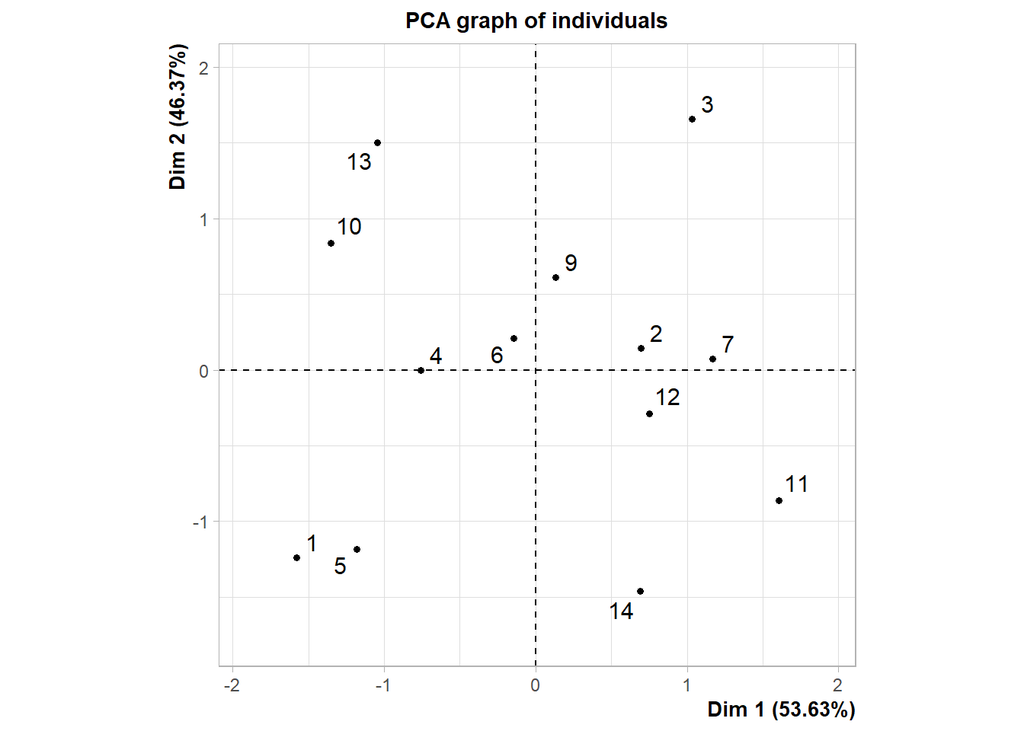

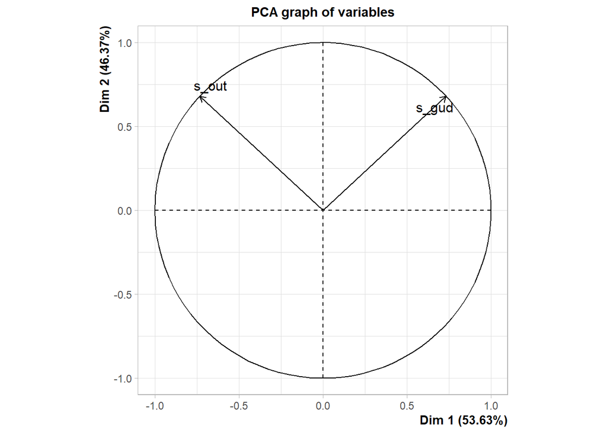

```
##
## Call:
## PCA(X = post[, c(32, 36)])
##
##
## Eigenvalues
##                        Dim.1   Dim.2
## Variance               1.073   0.927
## % of var.             53.627  46.373
## Cumulative % of var.  53.627 100.000
##
## Individuals (the 10 first)
##           Dist    Dim.1    ctr   cos2    Dim.2    ctr   cos2
## 1     |  2.008 | -1.580 17.914  0.620 | -1.238 12.709  0.380 |
## 2     |  0.710 |  0.695  3.460  0.958 |  0.146  0.176  0.042 |
## 3     |  1.954 |  1.034  7.661  0.280 |  1.659 22.818  0.720 |
## 4     |  0.758 | -0.758  4.125  1.000 | -0.003  0.000  0.000 |
## 5     |  1.673 | -1.182 10.015  0.499 | -1.185 11.637  0.501 |
## 6     |  0.253 | -0.145  0.151  0.329 |  0.207  0.357  0.671 |
## 7     |  1.168 |  1.165  9.740  0.996 |  0.073  0.044  0.004 |
## 9     |  0.626 |  0.129  0.119  0.043 |  0.612  3.109  0.957 |
## 10    |  1.592 | -1.354 13.140  0.723 |  0.837  5.814  0.277 |
## 11    |  1.821 |  1.604 18.456  0.776 | -0.863  6.175  0.224 |
##
## Variables
##          Dim.1    ctr   cos2    Dim.2    ctr   cos2
## s_out | -0.732 50.000  0.536 |  0.681 50.000  0.464 |
## s_gud |  0.732 50.000  0.536 |  0.681 50.000  0.464 |
```

```r
# Print PCA graph for behaviours contributing to proactive PCA slope
summary(PCA(post[,c(32, 36)]))
```

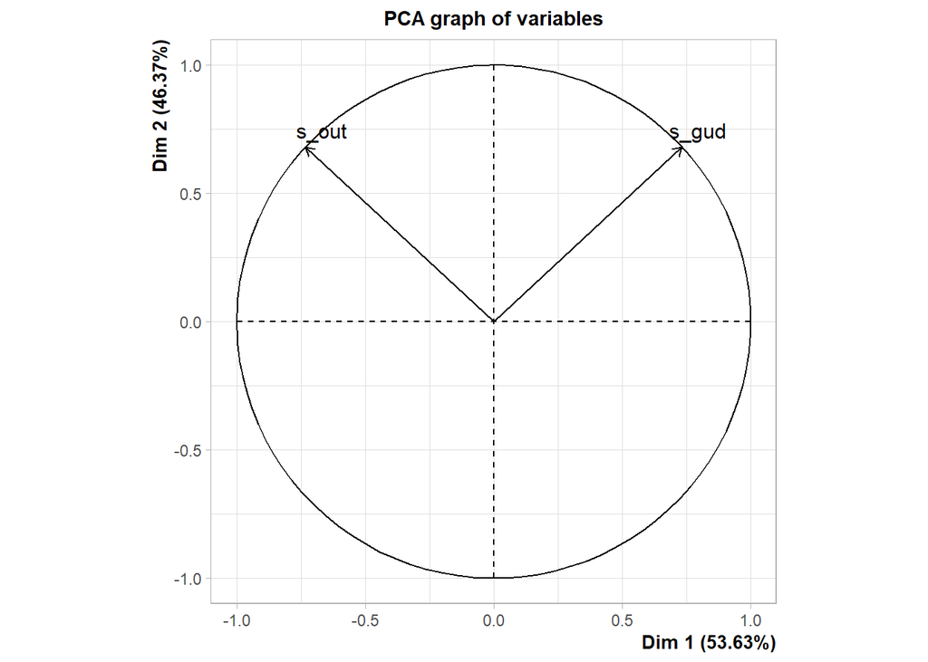

```r
# Extract first dimension value of proactive PCA slope
s_pro_pca <- get_pca_ind(PCA(post[,c(32, 36)]))
```

```r
s_pro_quoll <- data.frame(individual, s_pro_pca$coord) %>%
  dplyr::select(1, 2) %>%
  rename(s_pro_pca=Dim.1)
```

3. Extract first dimension value of reactive PCA for personality (intercept) for each animal.

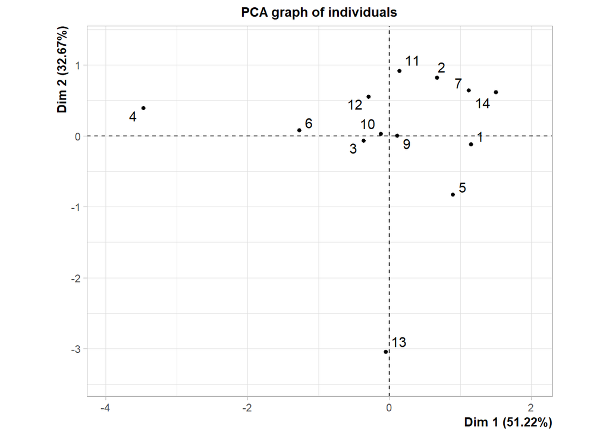

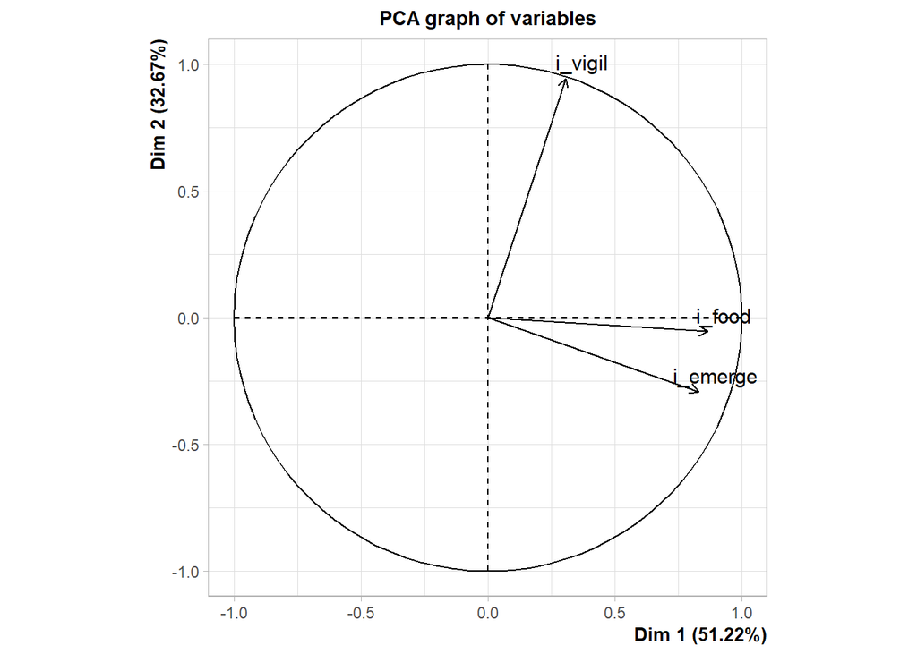

```
##
## Call:
## PCA(X = post[, c(23, 25, 29)])
##
##
## Eigenvalues
##                        Dim.1   Dim.2   Dim.3
## Variance               1.537   0.980   0.483
## % of var.             51.225  32.670  16.105
## Cumulative % of var.  51.225  83.895 100.000
##
## Individuals (the 10 first)
##              Dist    Dim.1    ctr   cos2    Dim.2    ctr   cos2    Dim.3    ctr
## 1        |  1.366 |  1.146  6.575  0.704 | -0.116  0.105  0.007 |  0.734  8.584
## 2        |  1.811 |  0.667  2.229  0.136 |  0.822  5.304  0.206 | -1.469 34.357
## 3        |  0.528 | -0.367  0.675  0.484 | -0.063  0.031  0.014 | -0.374  2.222
## 4        |  3.554 | -3.469 60.226  0.952 |  0.391  1.201  0.012 |  0.669  7.134
## 5        |  1.219 |  0.896  4.015  0.540 | -0.827  5.364  0.460 |  0.026  0.010
## 6        |  1.272 | -1.270  8.070  0.996 |  0.080  0.050  0.004 | -0.009  0.001
## 7        |  1.290 |  1.115  6.223  0.747 |  0.641  3.223  0.247 | -0.097  0.149
## 9        |  0.567 |  0.108  0.059  0.036 |  0.003  0.000  0.000 | -0.557  4.934
## 10       |  0.144 | -0.122  0.075  0.720 |  0.027  0.006  0.034 |  0.071  0.081
## 11       |  0.943 |  0.141  0.100  0.022 |  0.918  6.613  0.948 | -0.162  0.420
##            cos2
## 1         0.289 |
## 2         0.658 |
## 3         0.501 |
## 4         0.035 |
## 5         0.000 |
## 6         0.000 |
## 7         0.006 |
## 9         0.964 |
## 10        0.246 |
## 11        0.030 |
##
## Variables
##             Dim.1    ctr   cos2    Dim.2    ctr   cos2    Dim.3    ctr   cos2
## i_emerge |  0.831 44.959  0.691 | -0.292  8.685  0.085 |  0.473 46.356  0.224 |
## i_food   |  0.867 48.913  0.752 | -0.055  0.304  0.003 | -0.495 50.783  0.245 |
## i_vigil  |  0.307  6.128  0.094 |  0.944 91.011  0.892 |  0.118  2.861  0.014 |
```

```r
# Print PCA graph forbehaviours contributing to reactive PCA intercept
summary(PCA(post[,c(23, 25, 29)]))
```

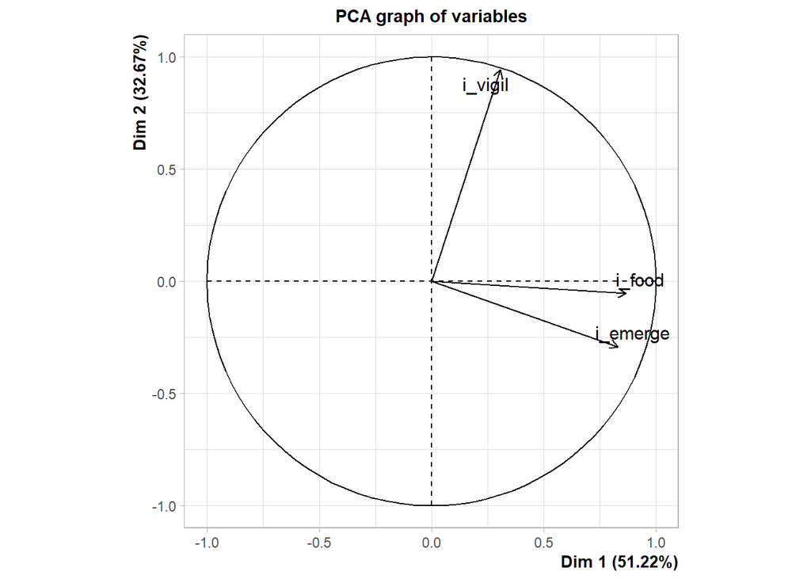

```r
# Extract first dimension value of reactive PCA intercept
i_rea_pca <- get_pca_ind(PCA(post[,c(23, 25, 29)]))
```

```r
i_rea_quoll <- data.frame(individual, i_rea_pca$coord) %>%
  dplyr::select(1, 2) %>%
  rename(i_rea_pca=Dim.1)
```

4. Extract first dimension value of reactive PCA for plasticity (slope) for each animal.

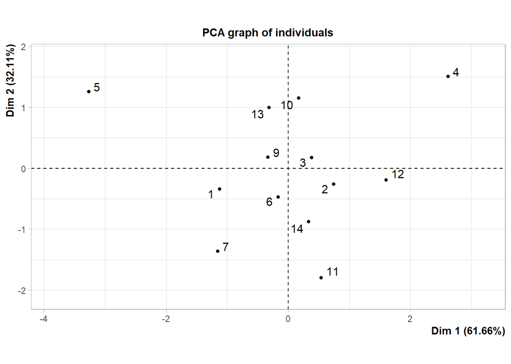

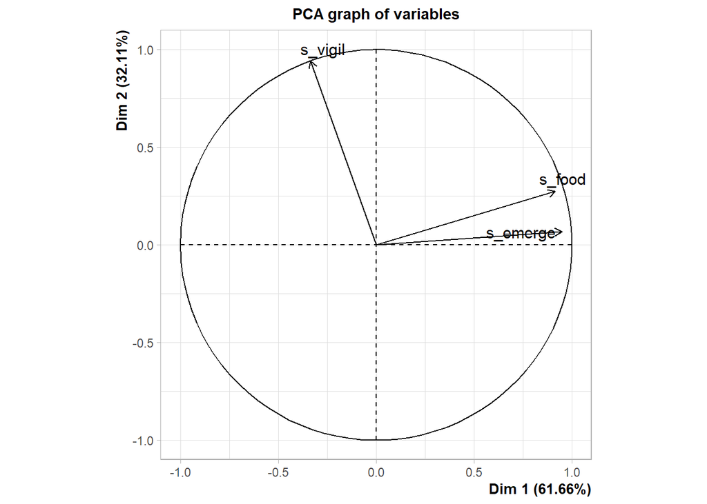

```
##
## Call:
## PCA(X = post[, c(24, 26, 30)])
##
##
## Eigenvalues
##                        Dim.1   Dim.2   Dim.3
## Variance               1.850   0.963   0.187
## % of var.             61.655  32.115   6.230
## Cumulative % of var.  61.655  93.770 100.000
##
## Individuals (the 10 first)
##              Dist    Dim.1    ctr   cos2    Dim.2    ctr   cos2    Dim.3    ctr
## 1        |  1.285 | -1.125  5.259  0.766 | -0.341  0.927  0.070 | -0.520 11.150
## 2        |  0.787 |  0.741  2.282  0.885 | -0.261  0.543  0.110 | -0.059  0.142
## 3        |  0.464 |  0.382  0.608  0.677 |  0.180  0.258  0.150 |  0.193  1.537
## 4        |  3.051 |  2.612 28.384  0.733 |  1.512 18.253  0.246 | -0.441  8.003
## 5        |  3.504 | -3.269 44.446  0.870 |  1.258 12.636  0.129 | -0.098  0.395
## 6        |  0.500 | -0.165  0.113  0.109 | -0.467  1.741  0.872 |  0.071  0.205
## 7        |  1.807 | -1.159  5.585  0.411 | -1.358 14.719  0.564 | -0.282  3.270
## 9        |  1.218 | -0.335  0.468  0.076 |  0.183  0.267  0.023 |  1.156 55.014
## 10       |  1.164 |  0.166  0.115  0.020 |  1.152 10.596  0.979 |  0.019  0.015
## 11       |  1.895 |  0.535  1.191  0.080 | -1.792 25.648  0.895 |  0.304  3.798
##            cos2
## 1         0.164 |
## 2         0.006 |
## 3         0.173 |
## 4         0.021 |
## 5         0.001 |
## 6         0.020 |
## 7         0.024 |
## 9         0.902 |
## 10        0.000 |
## 11        0.026 |
##
## Variables
##             Dim.1    ctr   cos2    Dim.2    ctr   cos2    Dim.3    ctr   cos2
## s_emerge |  0.949 48.681  0.900 |  0.067  0.471  0.005 |  0.308 50.848  0.095 |
## s_food   |  0.915 45.255  0.837 |  0.274  7.806  0.075 | -0.296 46.939  0.088 |
## s_vigil  | -0.335  6.064  0.112 |  0.940 91.723  0.884 |  0.064  2.213  0.004 |
```

```r
# Print PCA graph forbehaviours contributing to reactive PCA slope
summary(PCA(post[,c(24, 26, 30)]))
```

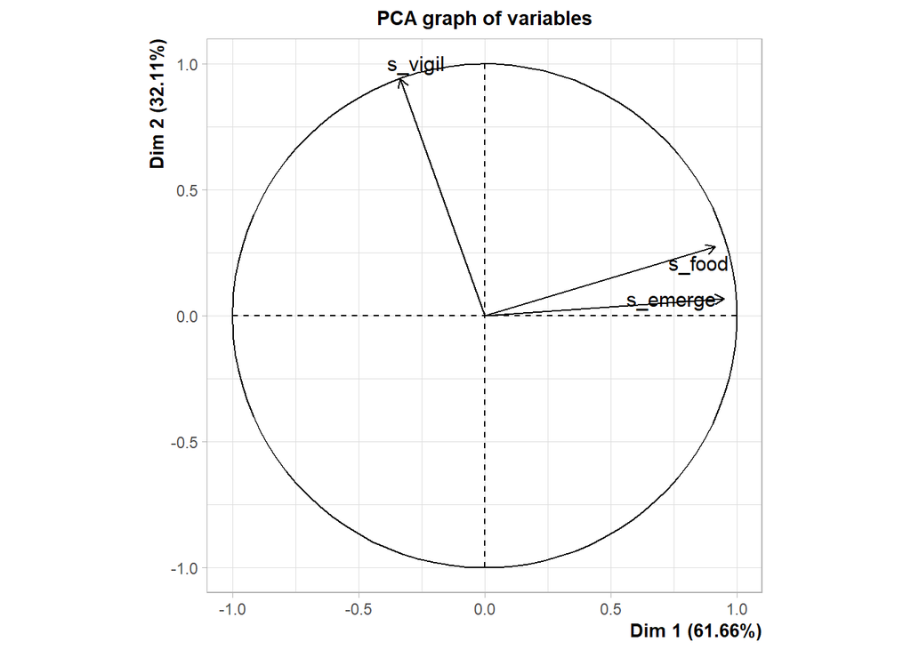

```r
# Extract first dimension value of reactive PCA slope
s_rea_pca <- get_pca_ind(PCA(post[,c(24, 26, 30)]))
```

```r
s_rea_quoll <- data.frame(individual, s_rea_pca$coord) %>%
  dplyr::select(1, 2) %>%
  rename(s_rea_pca=Dim.1)
```

```r
# Combine the PCA results
post_pca <- cbind(post, i_pro_quoll, s_pro_quoll,
                  i_rea_quoll, s_rea_quoll, by="individual")

# Write to csv file
write.csv(post_pca, "processed data/post-release PCAs.csv")
```

# 7 **Model behaviour by post-release responses**

- Survival responses (*n* = 13)
  1. `fate` (survived or died)
  2. Post-release `weight` (%)
- Dispersal responses (for animals that survived >7 days, *n* = 10, measured over 42 days)
  3. Number of `dens_used` (*n*)
  4. `mean_dist`ance travelled between dens per day (m)
  5. Days spent den sharing (*n*, `den_shared_days`)
  6. Home range (95% minimum convex polygon, `hr95`)

```r
# Read in post-release data
post <- read.csv("processed data/post-release PCAs.csv")

# Create df removing animals that did not survive >7 days
dispersal <- subset(post, individual!="EQ20" &
                      individual!="EQ29" &
                      individual!="EQ30") %>%
  mutate(hr95=as.numeric(hr95))

# Define column names to be used in later plots
predictors <- c("emerge","food","vigil","out",
                "gud","pro_pca","rea_pca")

# Define full behavioural measure labels to be used in plots
labels <- c("Latency to emerge (min)",
            "Latency to reach food (min)",
            "Time spent vigilant (s)",
            "Time spent exposed (s)",
            "Giving-up density (%)",
            "Proactive PC",
            "Reactive PC")
```

## 7.1 Fate

### 7.1.1 Models

```r
# Create blank df
plotdat <- data.frame()

# Loop to model each combination of behavioural measure intercept and slope
for (i in 1:7) {
  expr = as.formula(paste0("fate ~ i_",predictors[i]))
  mod <- brglm(expr, data=post, na.action="na.fail")
    effect <- data.frame(summary(mod)$coef)
    effect$label <- labels[i]
    effect$coefficient <- "Personality"
    effect$name <- row.names(effect)
  plotdat <- rbind(plotdat, effect)

  expr = as.formula(paste0("fate ~ s_",predictors[i]))
  mod <- brglm(expr, data=post, na.action="na.fail")
    effect <- data.frame(summary(mod)$coef)
    effect$label <- labels[i]
    effect$coefficient <- "Plasticity"
    effect$name <- row.names(effect)
  plotdat <- rbind(plotdat, effect)
}

# Define upper confidence interval
plotdat$upper <- plotdat$Estimate + (1.96*plotdat$Std..Error)

# Define lower confidence interval
plotdat$lower <- plotdat$Estimate - (1.96*plotdat$Std..Error)

plotdat <- subset(plotdat, name!="(Intercept)") %>%
  # Define p-value significance based on alpha 0.05
  mutate(sig = ifelse(Pr...z..<0.05, "sig", "nonsig"),
         # Reorder labels
         label = factor(label, levels=c("Reactive PC", "Proactive PC",
                                        "Giving-up density (%)",
                                        "Time spent vigilant (s)",
                                        "Time spent exposed (s)",
                                        "Latency to reach food (min)",
                                        "Latency to emerge (min)")))
fate_pd <- plotdat %>%
  select(p=Pr...z..)
```

### 7.1.2 Plot

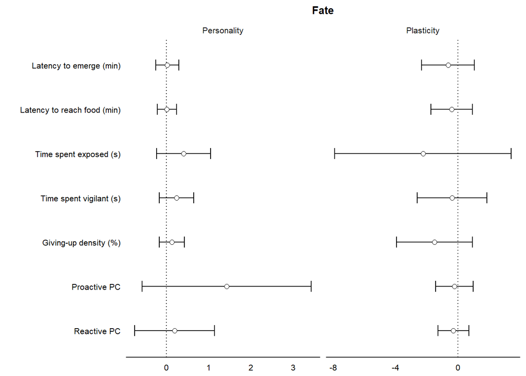

```r
# Create blank plot
plot=ggplot(data=plotdat, aes(x=Estimate,y=label,
                              xmin=lower, xmax=upper),
            ylab="", xlab="Effect size") + theme_bw()

# Plot
fig1 <- plot + ggtitle("Fate") +
  geom_vline(xintercept=0, linetype=3) +
  geom_errorbarh(height=0.25) +
  geom_point(stat="identity",aes(fill=factor(sig), size=sig),
             shape=21, colour="black", alpha=1) +
  xlab("") + ylab("") +
  theme(panel.grid.major = element_blank(),
        panel.grid.minor = element_blank(),
        panel.background = element_blank(),
        panel.border = element_blank(),
        axis.line.x = element_line(),
        text = element_text(size=10, colour="black"),
        plot.title = element_text(hjust=0.5, size=10, face="bold"),
        axis.text.y = element_text(angle=0, vjust=0.5,
                                   colour="black"),
        axis.text.x = element_text(angle=0, vjust=0,
                                 hjust=0.5, colour="black"),
        axis.ticks.y = element_blank(),
        axis.title.y = element_text(size=12),
        axis.ticks.x = element_blank(),
        axis.title.x = element_blank(),
        legend.position = "right",
        legend.justification = "top",
        strip.background = element_blank()) +
  scale_size_manual(values = c("sig"=6, "nonsig"=2)) +
  scale_fill_manual(values = c("sig"="black", "nonsig"="white"),
                    name="", guide=guide_legend(reverse=TRUE)) +
  guides(alpha="none", group="none", colour="none",
         fill="none", size="none") +
  facet_grid(~coefficient, scales="free")

# Display plot
print(fig1)
```

## 7.2 Weight

### 7.2.1 Models

```r
# Create blank df
plotdat <- data.frame()

# Loop to model each combination of behavioural measure intercept and slope
for (i in 1:7) {
  expr = as.formula(paste0("pr_weight ~ i_",predictors[i]))
  mod <- glm(expr, data=post, na.action="na.fail")
    effect <- data.frame(summary(mod)$coef)
    effect$label <- labels[i]
    effect$coefficient <- "Personality"
    effect$name <- row.names(effect)
  plotdat <-rbind(plotdat, effect)

  expr = as.formula(paste0("pr_weight ~ s_",predictors[i]))
  mod <- glm(expr, data=post, na.action="na.fail")
    effect <- data.frame(summary(mod)$coef)
    effect$label <- labels[i]
    effect$coefficient <- "Plasticity"
    effect$name <- row.names(effect)
  plotdat <-rbind(plotdat, effect)
}

# Define upper confidence interval
plotdat$upper <- plotdat$Estimate + (1.96*plotdat$Std..Error)

# Define lower confidence interval
plotdat$lower <- plotdat$Estimate - (1.96*plotdat$Std..Error)

plotdat <- subset(plotdat, name!="(Intercept)") %>%
  # Define p-value significance based on alpha 0.05
  mutate(sig = ifelse(Pr...t..<0.05, "sig", "nonsig"),
         # Reorder labels
         label = factor(label, levels=c("Reactive PC", "Proactive PC",
                                        "Giving-up density (%)",
                                        "Time spent vigilant (s)",
                                        "Time spent exposed (s)",
                                        "Latency to reach food (min)",
                                        "Latency to emerge (min)")))

weight_pd <- plotdat %>%
  select(p=Pr...t..)
```

### 7.2.2 Plot

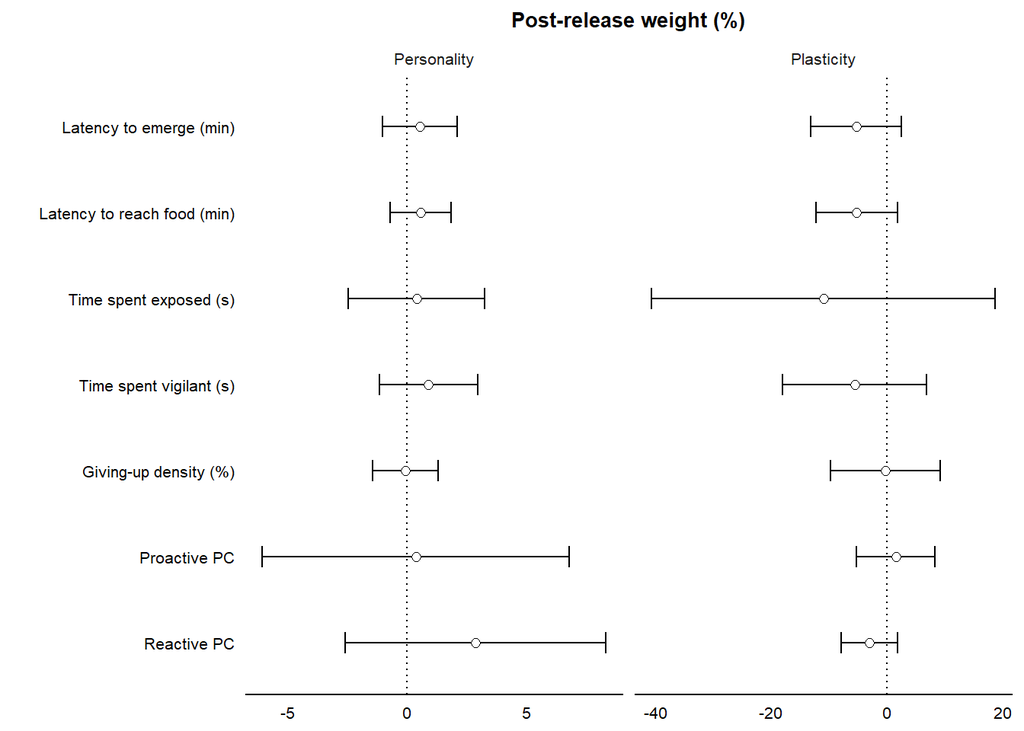

```r
# Create blank plot
plot=ggplot(data=plotdat, aes(x=Estimate,y=label,
                              xmin=lower, xmax=upper),
            ylab="", xlab="Effect size") + theme_bw()

# Plot
fig2 <- plot + ggtitle("Post-release weight (%)")+
  geom_vline(xintercept=0,linetype=3) +
  geom_errorbarh(height=0.25) +
  geom_point(stat="identity",aes(fill=factor(sig),size=sig),
             shape=21, colour="black", alpha=1) +
  xlab("") + ylab("") +
  theme(panel.grid.major = element_blank(),
        panel.grid.minor=element_blank(),
        panel.background = element_blank(),
        panel.border = element_blank(),
        axis.line.x = element_line(),
        text = element_text(size=10,colour="black"),
        plot.title = element_text(hjust=0.5, size=10, face="bold"),
        axis.text.y = element_text(angle=0, vjust=0.5, colour="black"),
        axis.text.x = element_text(angle=0, vjust=0.5, colour="black"),
        axis.ticks.y = element_blank(),
        axis.title = element_text(size=12),
        axis.ticks.x = element_blank(),
        axis.title.x = element_blank(),
        legend.position = "right",
        legend.justification = "top",
        strip.background = element_blank()) +
  scale_size_manual(values=c("sig"=6, "nonsig"=2)) +
  scale_fill_manual(values=c("sig"="black", "nonsig"="white"),
                    name="", guide=guide_legend(reverse=TRUE)) +
  guides(alpha="none", group="none", colour="none",
         fill="none", size="none") +
  facet_grid(~coefficient, scales="free")

# Display plot
print(fig2)
```

## 7.3 Number of dens used

### 7.3.1 Models

```r
# Create blank df
plotdat <- data.frame()

# Loop to model each combination of behavioural measure intercept and slope
for (i in 1:7) {
  expr = as.formula(paste0("dens_used ~ i_", predictors[i]))
  mod <- glm(expr, data=dispersal, na.action="na.fail")
    effect <- data.frame(summary(mod)$coef)
    effect$label <- labels[i]
    effect$coefficient <- "Personality"
    effect$name <- row.names(effect)
  plotdat <-rbind(plotdat, effect)

  expr = as.formula(paste0("dens_used ~ s_", predictors[i]))
  mod <- glm(expr, data=dispersal, na.action="na.fail")
    effect <- data.frame(summary(mod)$coef)
    effect$label <- labels[i]
    effect$coefficient <- "Plasticity"
    effect$name <- row.names(effect)
  plotdat <-rbind(plotdat, effect)
}

# Define upper confidence interval
plotdat$upper <- plotdat$Estimate + (1.96*plotdat$Std..Error)

# Define lower confidence interval
plotdat$lower <- plotdat$Estimate - (1.96*plotdat$Std..Error)

plotdat <- subset(plotdat,name!="(Intercept)") %>%
  # Define p-value significance based on alpha 0.05
  mutate(sig = ifelse(Pr...t..<0.05, "sig", "nonsig"),
         # Reorder labels
         label = factor(label, levels=c("Reactive PC", "Proactive PC",
                                        "Giving-up density (%)",
                                        "Time spent vigilant (s)",
                                        "Time spent exposed (s)",
                                        "Latency to reach food (min)",
                                        "Latency to emerge (min)")))

dens_pd <- plotdat %>%
  select(p=Pr...t..)
```

### 7.3.2 Plot

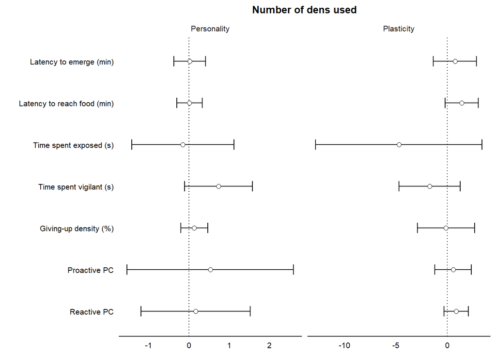

```r
# Create blank plot
plot=ggplot(data=plotdat, aes(x=Estimate,y=label,
                              xmin=lower, xmax=upper),
            ylab="", xlab="Effect size") + theme_bw()

# Plot
fig3 <- plot + ggtitle("Number of dens used")+
  geom_vline(xintercept=0,linetype=3) +
  geom_errorbarh(height=0.25) +
  geom_point(stat="identity",aes(fill=factor(sig),size=sig),
             shape=21, colour="black", alpha=1) +
  xlab("") + ylab("") +
  theme(panel.grid.major=element_blank(), panel.grid.minor=element_blank(),
        panel.background=element_blank(), panel.border=element_blank(),
        axis.line.x=element_line(), text=element_text(size=10,colour="black"),
        plot.title=element_text(hjust=0.5, size=10, face="bold"),
        axis.text.y=element_text(angle=0, vjust=0.5,colour="black"),
        axis.text.x=element_text(angle=0, vjust=0.5,colour="black"),
        axis.ticks.y=element_blank(), axis.title=element_text(size=12),
        axis.ticks.x=element_blank(), axis.title.x=element_blank(),
        legend.position="right", legend.justification="top",
        strip.background=element_blank()) +
  scale_size_manual(values=c("sig"=6, "nonsig"=2)) +
  scale_fill_manual(values=c("sig"="black", "nonsig"="white"),
                    name="", guide=guide_legend(reverse=TRUE)) +
  guides(alpha="none", group="none", colour="none", fill="none", size="none") +
  facet_grid(~coefficient, scales="free")

# Display plot
print(fig3)
```

## 7.4 Mean distance between dens

### 7.4.1 Models

```r
# Create blank df
plotdat <- data.frame()

# Loop to model each combination of behavioural measure intercept and slope
for (i in 1:7) {
  expr = as.formula(paste0("mean_dist ~ i_", predictors[i]))
  mod <- glm(expr, data=dispersal, na.action="na.fail")
    effect <- data.frame(summary(mod)$coef)
    effect$label <- labels[i]
    effect$coefficient <- "Personality"
    effect$name <- row.names(effect)
  plotdat <-rbind(plotdat, effect)

  expr = as.formula(paste0("mean_dist ~ s_", predictors[i]))
  mod <- glm(expr, data=dispersal, na.action="na.fail")
    effect <- data.frame(summary(mod)$coef)
    effect$label <- labels[i]
    effect$coefficient <- "Plasticity"
    effect$name <- row.names(effect)
  plotdat <-rbind(plotdat, effect)
}

# Define upper confidence interval
plotdat$upper <- plotdat$Estimate + (1.96*plotdat$Std..Error)

# Define lower confidence interval
plotdat$lower <- plotdat$Estimate - (1.96*plotdat$Std..Error)

plotdat <- subset(plotdat, name!="(Intercept)") %>%
  # Define p-value significance based on alpha 0.05
  mutate(sig = ifelse(Pr...t..<0.05, "sig", "nonsig"),
         # Reorder labels
         label = factor(label, levels=c("Reactive PC", "Proactive PC",
                                        "Giving-up density (%)",
                                        "Time spent vigilant (s)",
                                        "Time spent exposed (s)",
                                        "Latency to reach food (min)",
                                        "Latency to emerge (min)")))

dist_pd <- plotdat %>%
  select(p=Pr...t..)
```

### 7.4.2 Plot

```r
# Create blank plot
plot=ggplot(data=plotdat, aes(x=Estimate, y=label,
                              xmin=lower, xmax=upper),
            ylab="", xlab="Effect size") + theme_bw()

# Plot

names(plotdat)
```

```
##  [1] "Estimate"    "Std..Error"  "t.value"     "Pr...t.."    "label"
##  [6] "coefficient" "name"        "upper"       "lower"       "sig"
```

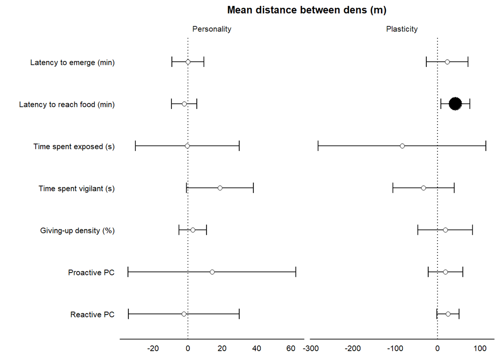

```r
fig4 <- plot + ggtitle("Mean distance between dens (m)")+
  geom_vline(xintercept=0,linetype=3) +
  geom_errorbarh(height=0.25) +
  geom_point(stat="identity",aes(fill=factor(sig),size=sig),
             shape=21, colour="black", alpha=1) +
  xlab("") + ylab("") +
  theme(panel.grid.major=element_blank(), panel.grid.minor=element_blank(),
        panel.background=element_blank(), panel.border=element_blank(),
        axis.line.x=element_line(), text=element_text(size=10,colour="black"),
        plot.title=element_text(hjust=0.5, size=10, face="bold"),
        axis.text.y=element_text(angle=0, vjust=0.5,colour="black"),
        axis.text.x=element_text(angle=0, vjust=0.5,colour="black"),
        axis.ticks.y=element_blank(), axis.title=element_text(size=12),
        axis.ticks.x=element_blank(), axis.title.x=element_blank(),
        legend.position="right", legend.justification="top",
        strip.background=element_blank()) +
  scale_size_manual(values=c("sig"=6, "nonsig"=2)) +
  scale_fill_manual(values=c("sig"="black", "nonsig"="white"),
                    name="", guide=guide_legend(reverse=TRUE)) +
  guides(alpha="none", group="none", colour="none", fill="none", size="none") +
  facet_grid(~coefficient, scales="free")

# Display plot
print(fig4)
```

## 7.5 Days spent den sharing

### 7.5.1 Models

```r
# Create blank df
plotdat <- data.frame()

# Loop to model each combination of behavioural measure intercept and slope
for (i in 1:7) {
  expr = as.formula(paste0("den_shared_days ~ i_", predictors[i]))
  mod <- glm(expr, data=dispersal, na.action="na.fail")
    effect <- data.frame(summary(mod)$coef)
    effect$label <- labels[i]
    effect$coefficient <- "Personality"
    effect$name <- row.names(effect)
  plotdat <-rbind(plotdat, effect)

  expr = as.formula(paste0("den_shared_days ~ s_", predictors[i]))
  mod <- glm(expr, data=dispersal, na.action="na.fail")
    effect <- data.frame(summary(mod)$coef)
    effect$label <- labels[i]
    effect$coefficient <- "Plasticity"
    effect$name <- row.names(effect)
  plotdat <-rbind(plotdat, effect)
}

# Define upper confidence interval
plotdat$upper <- plotdat$Estimate + (1.96*plotdat$Std..Error)

# Define lower confidence interval
plotdat$lower <- plotdat$Estimate - (1.96*plotdat$Std..Error)

plotdat <- subset(plotdat,name!="(Intercept)") %>%
  # Define p-value significance based on alpha 0.05
  mutate(sig = ifelse(Pr...t..<0.05, "sig", "nonsig"),
         # Reorder labels
         label = factor(label, levels=c("Reactive PC", "Proactive PC",
                                        "Giving-up density (%)",
                                        "Time spent vigilant (s)",
                                        "Time spent exposed (s)",
                                        "Latency to reach food (min)",
                                        "Latency to emerge (min)")))

share_pd <- plotdat %>%
  select(p=Pr...t..)
```

### 7.5.2 Plot

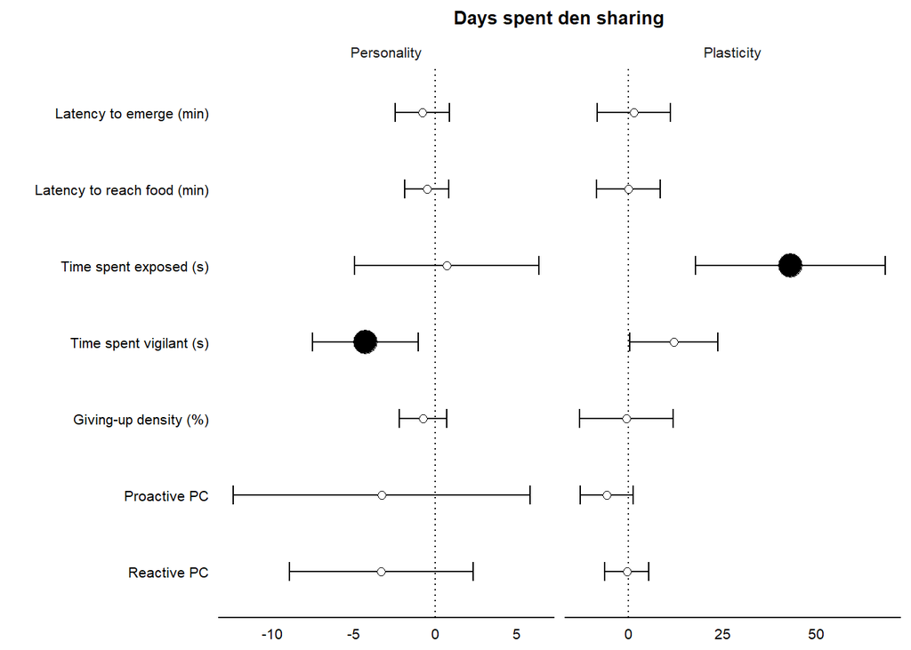

```r
# Create a blank plot
plot=ggplot(data=plotdat, aes(x=Estimate, y=label,
                              xmin=lower, xmax=upper),
            ylab="", xlab="Effect size") + theme_bw()

# Plot
fig5 <- plot + ggtitle("Days spent den sharing")+
  geom_vline(xintercept=0,linetype=3) +
  geom_errorbarh(height=0.25) +
  geom_point(stat="identity",aes(fill=factor(sig), size=sig),
             shape=21, colour="black", alpha=1) +
  xlab("") + ylab("") +
  theme(panel.grid.major=element_blank(),
        panel.grid.minor=element_blank(),
        panel.background=element_blank(),
        panel.border=element_blank(),
        axis.line.x=element_line(),
        text=element_text(size=10,colour="black"),
        plot.title=element_text(hjust=0.5, size=10, face="bold"),
        axis.text.y=element_text(angle=0, vjust=0.5, colour="black"),
        axis.text.x=element_text(angle=0, vjust=0.5, colour="black"),
        axis.ticks.y=element_blank(),
        axis.title=element_text(size=12),
        axis.ticks.x=element_blank(),
        axis.title.x=element_blank(),
        legend.position="right",
        legend.justification="top",
        strip.background=element_blank()) +
  scale_size_manual(values=c("sig"=6, "nonsig"=2)) +
  scale_fill_manual(values=c("sig"="black", "nonsig"="white"),
                    name="", guide=guide_legend(reverse=TRUE)) +
  guides(alpha="none", group="none", colour="none",
         fill="none", size="none") +
  facet_grid(~coefficient, scales="free")

# Display plot
print(fig5)
```

## 7.6 Home range

### 7.6.1 Models

```r
# Create blank df
plotdat <- data.frame()

# Loop to model each combination of behavioural measure intercept and slope
for (i in 1:7) {
  expr = as.formula(paste0("hr95 ~ i_",predictors[i]))
  mod <- glm(expr, data=dispersal, na.action="na.fail")
    effect <- data.frame(summary(mod)$coef)
    effect$label <- labels[i]
    effect$coefficient <- "Personality"
    effect$name <- row.names(effect)
  plotdat <-rbind(plotdat, effect)

  expr = as.formula(paste0("hr95 ~ s_",predictors[i]))
  mod <- glm(expr, data=dispersal, na.action="na.fail")
    effect <- data.frame(summary(mod)$coef)
    effect$label <- labels[i]
    effect$coefficient <- "Plasticity"
    effect$name <- row.names(effect)
  plotdat <-rbind(plotdat, effect)
}

# Define upper confidence interval
plotdat$upper <- plotdat$Estimate + (1.96*plotdat$Std..Error)

# Define lower confidence interval
plotdat$lower <- plotdat$Estimate - (1.96*plotdat$Std..Error)

plotdat <- subset(plotdat,name!="(Intercept)") %>%
  # Define p-value significance based on alpha 0.05
  mutate(sig = ifelse(Pr...t..<0.05, "sig", "nonsig"),
         # Reorder labels
         label = factor(label, levels=c("Reactive PC", "Proactive PC",
                                        "Giving-up density (%)",
                                        "Time spent vigilant (s)",
                                        "Time spent exposed (s)",
                                        "Latency to reach food (min)",
                                        "Latency to emerge (min)")))

hr_pd <- plotdat %>%
  select(p=Pr...t..)
```

### 7.6.2 Plot

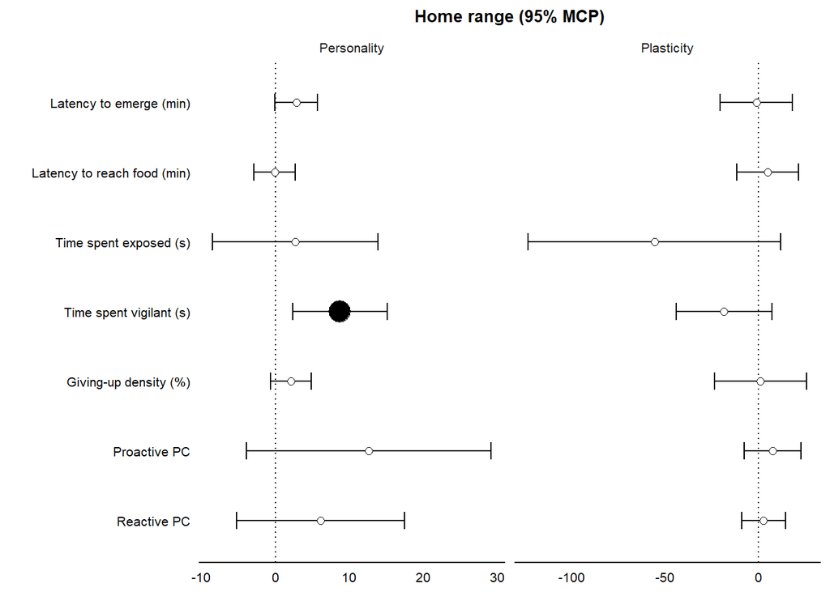

```r
# Create blank plot
plot=ggplot(data=plotdat, aes(x=Estimate,y=label,
                              xmin=lower, xmax=upper),
            ylab="", xlab="Effect size") + theme_bw()

# Plot
fig6 <- plot + ggtitle("Home range (95% MCP)")+
  geom_vline(xintercept=0, linetype=3) +
  geom_errorbarh(height=0.25) +
  geom_point(stat="identity", aes(fill=factor(sig), size=sig),
             shape=21, colour="black", alpha=1) +
  xlab("") + ylab("") +
  theme(panel.grid.major=element_blank(),
        panel.grid.minor=element_blank(),
        panel.background=element_blank(),
        panel.border=element_blank(),
        axis.line.x=element_line(),
        text=element_text(size=10,colour="black"),
        plot.title=element_text(hjust=0.5, size=10, face="bold"),
        axis.text.y=element_text(angle=0, vjust=0.5, colour="black"),
        axis.text.x=element_text(angle=0, vjust=0.5, colour="black"),
        axis.ticks.y=element_blank(),
        axis.title=element_text(size=12),
        axis.ticks.x=element_blank(),
        axis.title.x=element_blank(),
        legend.position="right",
        legend.justification="top",
        strip.background=element_blank()) +
  scale_size_manual(values=c("sig"=6, "nonsig"=2)) +
  scale_fill_manual(values=c("sig"="black", "nonsig"="white"),
                    name="", guide=guide_legend(reverse=TRUE)) +
  guides(alpha="none", group="none", colour="none",
         fill="none", size="none") +
  facet_grid(~coefficient, scales="free")

# Display plot
print(fig6)
```

## 7.7 Composite effect size plot

Finally, we combine the plots created above into a single composite figure.

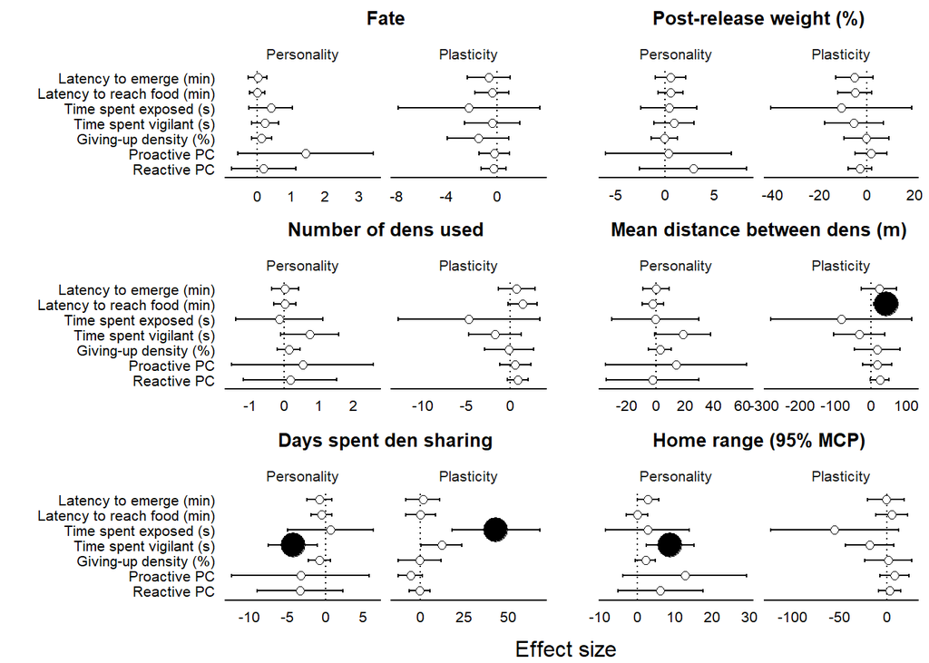

```r
# Arrange the effect size plots into a single plot
effects <- ggarrange(fig1, fig2 + rremove("y.text"),
                     fig3, fig4 + rremove("y.text"),
                     fig5, fig6 + rremove("y.text"),
                     heights=c(3,3,3), widths=c(4.5,3,3),
                     ncol=2, nrow=3, label.x=0.89, label.y=0.99,
                     font.label=list(size=10, face="bold", color ="black"),
                     hjust=-0.1, vjust=1.5)

# Annotate a title to the plot
effects <- annotate_figure(effects,
                           bottom=text_grob("Effect size", hjust=-0.5))

# Display plot
print(effects)
```